# An introduction to Momocs

Vincent Bonhomme

2018-10-22

## Preliminaries

### News

Momocs is being extensively polished these days and may evolve before its 2.0 release as prt of [MomX](http://momx.online). – October 2018

### Abstract

Momocs aims to provide a complete and convenient toolkit for morphometrics. It is intended for scientists interested in describing quantitatively the shape, and its (co)variations, of the objects they study.

In the last decade, R has become the open-source *lingua franca* for statistics, and morphometrics known its so-called “revolution”. Nevertheless, morphometric analyses still have to be carried out using various software packages either dedicated to a particular morphometric and/or for which source code is mostly unavailable and/or copyrighted. Moreover, most of existing software packages cannot be extended and their bugs are hard to detect and thus correct. This situation is detrimental to morphometrics: time is wasted, analyses are restricted to available methods, and last but not least, are poorly reproducible. This impedes collaborative effort both in software development and in morphometric studies.

By gathering the common morphometric approaches in an open-source environment and welcoming contributions, Momocs is an attempt to solve this twofold problem.

Momocs hinges on the core functions published in the must-have *[Morphometrics with R](http://www.springer.com/us/book/9780387777894)* by [Julien Claude](http://www.isem.univ-montp2.fr/recherche/equipes/macroevolution-et-developpement/personnel/claude-julien/) (2008), but has been further extended to allow other shape description systems. So far, configurations of landmarks, outlines and open outline analyses, along with some facilities for traditional morphometrics are implemented.

Prior to analysis, Momocs can be used to acquire and manipulate data or to import/export from/to other formats. Momocs also has the facility for a wide range of multivariate analyses and production of the companion graphics. Thus a researcher will find that just a few lines of code will provide initial results, but the methods implemented can be finely tuned and extended according to the user’s needs.

- If you use it, please cite it: `citation("Momocs")`.
- This citation refers to an obsolete version of Momocs, only handling outline analyses. The next companion, encompassing all [MomX](http://momx.online) and seminal paper is on its way.

### Survival tips

- This vignette introduces Momocs, as for every R function, each function has its own manual page, eg `?efourier`.
- There is a much nicer [online version of this manual](http://momx.github.io/Momocs/) that can be accessed from the console with, e.g. `Momocs_help("efourier")`.
- Feel free to contribute to Momocs through [GitHub](http://www.github.com/MomX/Momocs): report issues, ask for new features, share data and methods, correct typos, write better vignettes, helpfiles, or whatever pleases you. If you have never heard of GitHub, that’s definitely worth [a look](http://r-pkgs.had.co.nz/git.html).
- Feel free to drop me a line, should you need a hand or would like to collaborate with me: `bonhomme.vincent@gmail.com`.

### Get, install and use it

First, of all, let’s download the last version of Momocs. You will need to install the `devtools` package to get it from my [GitHub](http://www.github.com/MomX/Momocs) repository :

```r
install.packages("devtools")
devtools::install_github("MomX/Momocs")
```

The typical `install_packages("Momocs")` will get you the last CRAN version of Momocs, but the GitHub version is preferred as Momocs is still under active development.

We can start using Momocs, as long as it has been loaded using:

```r
library(Momocs)
```

## Design

Keywords used all accross Momocs are introduced here in **bold**.

Morphometrics is the ugly job of turning beautiful shapes into quantitative variables. Just kidding, that’s pretty exciting.

A **shape** is defined as a collection of `(x; y)` coordinates. No 3D yet but different **families** can be handled: **outlines**, here in a first-quarter moon ; **open outlines**, here is the sterile valve of an olive stone; **configuration of landmarks**; here, hologous points from a mosquito wing.

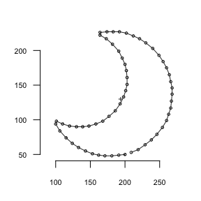

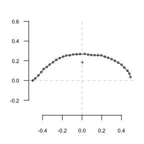

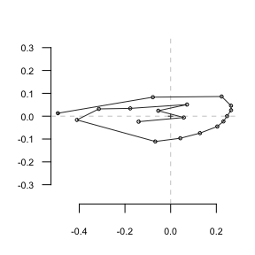

They are all single shapes defined by a matrix of `(x; y)` coordinates; here are the first points of the moon:

```r
shapes[18] %>% head()
```

```
##      [,1] [,2]
## [1,]  200   50
## [2,]  199   49
## [3,]  198   49
## [4,]  197   50
## [5,]  196   50
## [6,]  195   49
```

A few dozens of operations on single shapes are implemented such as: plotting, centering, calculating areas, etc. These 70+ operations can be accessed with `apropos("coo_")`. But working on single shapes is quite boring.

Shapes can be organized into a **collection** of coordinates: a `Coo` object that carries:

- a component named `$coo`, a `list` of shapes (as `matrix`.ces);
- most of the time, a component named `$fac`, a `data.frame` to store covariates, either `factor`s or `numeric`s;
- possibly, other components of interest.

One can do several things with a `Coo` object: visualize it, apply morphometric operations, handle the data it contains, but in the end, a __ morphometric method__ will turn coordinates into coefficients.

Such morphometric operation on coordinates produce a collection of coefficients: a `Coe` object that carries:

- a component named `$coe`, a `matrix` of coefficients;
- if present in `Coo`, `$fac` is inherited;
- possibly, other components of interest.

This can be summarized as follows:

| `Coo` | + | Morphometric method | = | `Coe` |
| --- | --- | --- | --- | --- |
| `(x; y)` coordinates | + | appropriate method | = | quantitative variables |

`Coo` objects are collections of coordinates that become `Coe` objects when an appropriate morphometric method is applied on them.

Some operations on `Coo`/`Coe` are **generic** in that they do not depend of the nature of the shape. For instance, centering a configuration of landmarks or an outline, or calculating their centroid size is, mathematically, the same **generic** operation. But some operations on shapes are **specific** to a peculiar family. For instance, calculating elliptical Fourier transforms on a configuration of landmarks would make no sense.

Momocs implement this desirable behavior and defines **classes** and **subclasses**, as S3 objects.

| `Coo` | Morphometrics methods | `Coe` |
| --- | --- | --- |
| `OutCoo` (outlines) | `efourier`, `rfourier`, `sfourier`, `tfourier` | `OutCoe` |
| `OpnCoo` (open outlines) | `npoly`, `opoly`, `dfourier` | `OpnCoe` |
| `LdkCoo` (configuration of landmarks) | `fgProcrustes`, `slide` | `LdkCoe` |

In other words:

- any collection of shapes belongs to (pick one) `{OutCoo, OpnCoo, LdkCoo}` and is also a `Coo` object;
- generic and specific methods can be applied to it
- a collection of coefficients is obtain and belongs to (pick one) `{OutCoe, OpnCoe, LdkCoe}` and is also a `Coe` object.

Finally, generic and specific operations can be applied to the `Coe` objects, chiefly multivariate methods, capitalicized: `PCA`, `LDA`, `CLUST`, `MANOVA`(and MANCOVA), `MSHAPES`, `KMEANS`, etc.

Overall, Momocs implements a simple and consistent grammar that is detailed below. Also, if you’re familiar with modern R and the Hadley-verse, you should feel home as `ggplot2` graphics, `dplyr` verbs and `magrittr` pipes are implemented.

## Single shapes

Let’s load one of the Momocs datasets, some various outlines (an `Out` object):

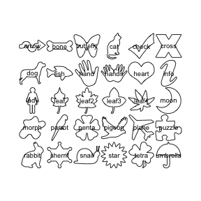

```
## Out (outlines)
##   - 30 outlines, 836 +/- 255 coords (in $coo)
##   - 0 classifiers (in $fac):
## # A tibble: 0 x 0
##   - also: $ldk
```

```r
shapes                    # prints a brief summary
panel(shapes, names=TRUE) # base graphics
```

`shapes` is one of the datasets bundled with Momocs. It’s (“lazy”) loaded in memory as soon as you call it, no need for `data(shapes)`. To see all Momocs’ datasets, try `data(package="Momocs")`. These datasets are all `Coo` objects (try `class(bot)`), ie collection of shapes.

One can do many things on a `Coo` object, as above, e.g. printing a summary of it (just by typing its name in the console), plotting a family picture with `panel` or `panel2`. Note the `2` that refers to a `ggplot2` variant of a given plot.

So far, we’re interested in single shapes so let’s extract the 4th shape from `shapes`, using the traditional syntax. We plot it with `coo_plot` that comes with several options for plotting all families of shapes.

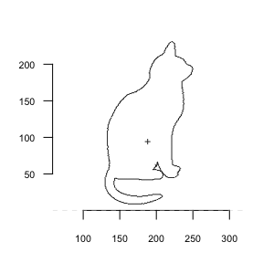

```r
shp <- shapes[4]
coo_plot(shp)
```

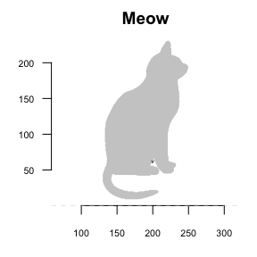

```r
# coo_plot is the base plotter for shapes
# but it can be finely customized, see ?coo_plot
coo_plot(shp, col="grey80", border=NA, centroid=FALSE, main="Meow")
```

Let’s now do some basic operations on this shape. They all named `coo_*` and you can have the full list with `apropos("coo_")`. `coo_*` family encompasses:

- geometric operations (such as centering, scaling, etc.)
- plotting functions
- scalar descriptors of shape (such as area, perimeter, circularity, rectilinearity, etc.)
- various other operations on a single shape.

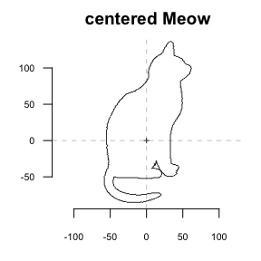

```r
coo_plot(coo_center(shp), main="centered Meow")
```

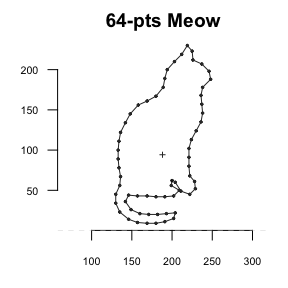

```r
coo_plot(coo_sample(shp, 64), points=TRUE, pch=20, main="64-pts Meow")
```

Momocs makes use of [maggritr](https://CRAN.R-project.org/package=magrittr)’s pipe operators. A nice introduction can be found [there](https://CRAN.R-project.org/package=magrittr). `magrittr` requires a (very small) cerebral gymnastics at the beginning but the benefits are huge, for defining moprhometric pipelines in Momocs but also for R as a whole. It makes things clearer, it: saves typing; reduces intermediate variable assignation; reads from left to right; substantiates the pipe we (should) have in mind. `magrittr`’s pipes are already loaded with Momocs.

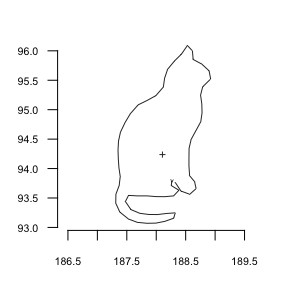

```r
shapes[4] %>% coo_smooth(5) %>% coo_sample(64) %>% coo_scale() %>% coo_plot()
```

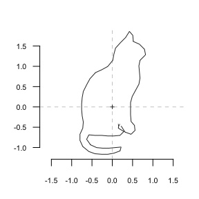

```r
# pipes can be turned into custom function
cs64 <- function(x) x %>% coo_sample(64) %>% coo_scale() %>% coo_center()
shapes[4] %>% cs64 %>% coo_plot() # note the axes
```

The most familiar operation can directly be applied on `Coo` objects:

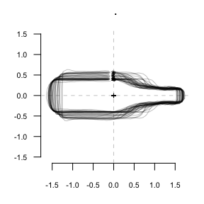

```
## Out (outlines)
##   - 40 outlines, 162 +/- 21 coords (in $coo)
##   - 3 classifiers (in $fac):
## # A tibble: 40 x 3
##   type   fake     cs
##   <fct>  <fct> <dbl>
## 1 whisky a      335.
## 2 whisky a      307.
## 3 whisky a      220.
## 4 whisky a      245.
## 5 whisky a      277.
## 6 whisky a      210.
## # ... with 34 more rows
##   - also: $ldk
```

```r
bot %>%
coo_center %>% coo_scale %>%
coo_alignxax() %>% coo_slidedirection("up") %T>%
print() %>% stack()
```

## Morphometrics

### Outline analysis

A word about data import: you can extract outlines from a list of black masks over a white background, as `.jpg` images with `import_jpg`. Have a look to helpfiles (`import_jpg` and `import_jpg1`) for more details. Here we do not bother with import since we will use the `bot`tles outlines dataset bundled with Momocs.

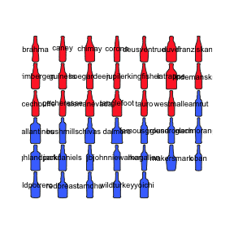

```r
data(bot)
bot
panel(bot, fac="type", names=TRUE)
```

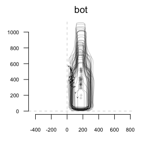

```
## Out (outlines)
##   - 40 outlines, 162 +/- 21 coords (in $coo)
##   - 2 classifiers (in $fac):
## # A tibble: 40 x 2
##   type   fake
##   <fct>  <fct>
## 1 whisky a
## 2 whisky a
## 3 whisky a
## 4 whisky a
## 5 whisky a
## 6 whisky a
## # ... with 34 more rows
##   - also: $ldk
```

```r
stack(bot)
```

Here we will illustrate outline analysis with some elliptical Fourier transforms (but the less used - and tested - radii variation Fourier transforms, its variant used by Renaud et al., and tangent angle Fourier transforms are also implemented with `rfourier`, `sfourier` and `tfourier` respectively).

The idea behind elliptical Fourier transforms is to fit the x and y coordinates separately, that is the blue and red curves below:

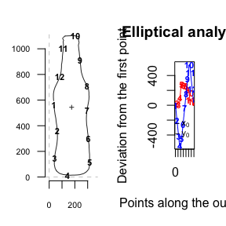

```
## # A tibble: 138 x 2
##       dx    dy
##    <dbl> <dbl>
##  1     0     0
##  2     3   -21
##  3     3   -32
##  4     6   -53
##  5     9   -74
##  6    11   -84
##  7    15  -105
##  8    17  -126
##  9    20  -147
## 10    22  -158
## # ... with 128 more rows
```

```r
coo_oscillo(bot[1], "efourier")
```

Graphically, this is equivalent to fitting Ptolemaic ellipses on the plane:

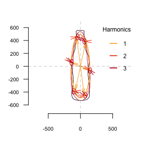

```r
Ptolemy(bot[1])
```

Let’s calibrate the number of harmonics required. More details can be found in their respective help files.

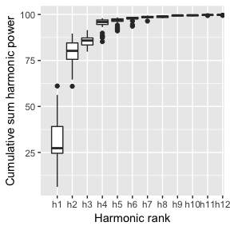

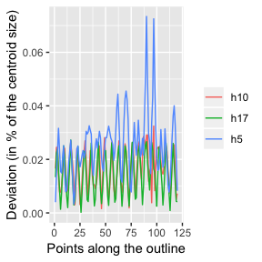

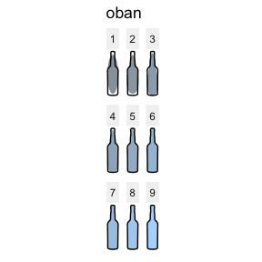

```
## $gg
##
## $q
##                       h1       h2       h3       h4       h5       h6
## brahma         12.015183 75.77538 84.07922 96.10181 97.34168 98.77976
## caney          25.287301 83.68491 85.38833 97.47106 97.79524 98.32091
## chimay         43.421561 81.54716 86.94665 94.96776 97.39247 98.02442
## corona         18.705505 84.76069 86.29248 96.75231 97.17090 97.83694
## deusventrue    49.960794 89.62993 91.50776 97.37525 98.13378 98.78278
## duvel          43.733170 79.77505 88.14345 93.10172 96.38315 96.68583
## franziskaner   19.307641 80.48552 86.97152 95.60206 96.27931 98.23548
## grimbergen     38.816119 85.20063 87.51264 96.99263 97.57349 97.77877
## guiness        33.238446 80.80898 85.81759 96.51499 97.51998 97.97861
## hoegardeen     25.800395 83.96335 85.84893 97.06527 97.52610 98.40888
## jupiler        24.312112 84.66358 86.03794 97.54700 97.85975 98.70747
## kingfisher     26.135594 84.48777 88.04188 97.17552 97.65600 98.55744
## latrappe       40.006966 67.94796 83.40047 87.90448 94.38216 96.89498
## lindemanskriek 33.668625 84.76379 87.14975 97.23196 97.82567 98.57729
## nicechouffe    38.595506 84.52704 88.31686 96.60627 97.58948 98.32637
## pecheresse     25.817934 84.80965 85.96765 97.04553 97.40322 98.61866
##                      h7       h8       h9      h10      h11      h12
## brahma         98.93834 98.96885 99.35135 99.49083 99.78892 99.83907
## caney          98.58170 98.93137 99.66487 99.76105 99.83464 99.83984
## chimay         98.84439 98.90095 99.68603 99.70994 99.75952 99.76441
## corona         98.18097 98.99520 99.49044 99.56051 99.63586 99.64366
## deusventrue    99.43345 99.48470 99.74104 99.74521 99.88867 99.88932
## duvel          98.45994 98.63711 99.66225 99.68683 99.73484 99.80925
## franziskaner   98.66182 98.93920 99.37315 99.44664 99.73243 99.74755
## grimbergen     98.37062 98.76975 99.70911 99.78080 99.79771 99.81567
## guiness        98.35037 98.36662 99.44825 99.59655 99.80284 99.80681
## hoegardeen     98.75081 99.09224 99.51903 99.59162 99.77548 99.79636
## jupiler        98.99411 99.33156 99.71026 99.75434 99.88047 99.89240
## kingfisher     98.88940 99.15843 99.51806 99.56392 99.74486 99.77429
## latrappe       99.16748 99.31723 99.59669 99.61555 99.69219 99.74053
## lindemanskriek 99.04016 99.22543 99.60968 99.61839 99.85332 99.86514
## nicechouffe    99.00682 99.12873 99.60201 99.61001 99.85551 99.86228
## pecheresse     99.00885 99.37037 99.68087 99.71826 99.88329 99.89623
##                     h13      h14      h15      h16      h17      h18
## brahma         99.89334 99.90228 99.92438 99.93392 99.94305 99.94815
## caney          99.91300 99.92991 99.93952 99.94303 99.94993 99.95194
```

[output cut: 123 more lines]

```
## franziskaner   99.99898 99.99921 99.99948 99.99993 100
## grimbergen     99.99930 99.99963 99.99986 99.99992 100
## guiness        99.99828 99.99859 99.99890 99.99925 100
## hoegardeen     99.99970 99.99972 99.99978 99.99991 100
## jupiler        99.99972 99.99978 99.99987 99.99994 100
## kingfisher     99.99840 99.99866 99.99894 99.99954 100
## latrappe       99.99980 99.99981 99.99984 99.99991 100
## lindemanskriek 99.99970 99.99973 99.99978 99.99998 100
## nicechouffe    99.99975 99.99980 99.99985 99.99998 100
## pecheresse     99.99977 99.99980 99.99992 99.99993 100
##  [ getOption("max.print") est atteint -- 24 lignes omises ]
##
## $minh
##   90%   95%   99% 99.9%
##     5     5    10    17
```

Here, 10 harmonics gather 99% of the harmonic power. If you’re happy with this criterium, you can even omit `nb.h` in `efourier`: that’s the default parameter, returned with a message.

```r
bot.f <- efourier(bot, nb.h=10)
bot.f
```

```
## An OutCoe object [ elliptical Fourier analysis ]
## --------------------
##  - $coe: 40 outlines described, 10 harmonics
## # A tibble: 40 x 2
##   type   fake
##   <fct>  <fct>
## 1 whisky a
## 2 whisky a
## 3 whisky a
## 4 whisky a
## 5 whisky a
## 6 whisky a
## # ... with 34 more rows
```

`bot.f` is a `Coe` object (and even an `OutCoe`), you have have a look to the help files to go deeper into Momocs classes.

Let’s have a look to the amplitude of fitted coefficients.

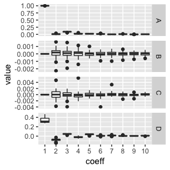

```r
# hist(bot.f, drop=0)
boxplot(bot.f, drop=1)
```

Now, we can calculate a PCA on the `Coe` object and plot it, along with morphospaces, calculated on the fly.

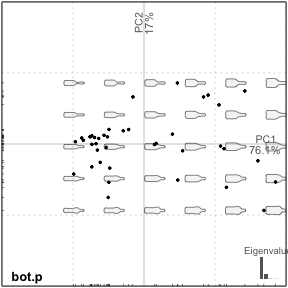

```
## [1] "PCA"    "prcomp"
```

```r
bot.p <- PCA(bot.f)
class(bot.p)        # a PCA object, let's plot it
plot(bot.p)
```

Amazing but we will do much better afterwards.

The question of normalization in elliptical Fourier transforms is central. Normalization can either be done beforehand, with geometric operations, or afterhand, directly on the matrix of Fourier coefficients and consuming the first harmonic. In brief, I’m not a big fan of the “use the first harmonics and see what happens” strategy, as some biases can be introduced (and actually quite hard to detect), particularly on rounded/ellipsoid shapes. More can be found in `?efourier`.

Here is an example of such bias from the `molars` dataset generously shared by Cornu and Detroit.

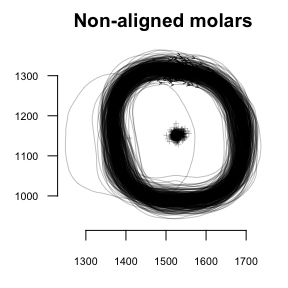

```r
# raw molars dataset
stack(molars, title = "Non-aligned molars")
```

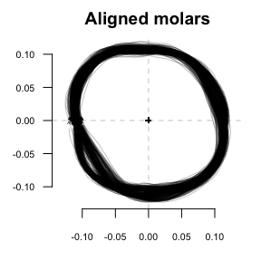

```r
# Procrustes-aligned and slided molars
mol.al <- fgProcrustes(molars, tol = 1e-4) %>% coo_slidedirection("left")
stack(mol.al, title="Aligned molars")
```

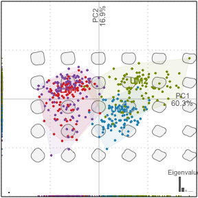

```r
# Now compare PCA and morphospace using the 1st harmonic alignment
molars %>% efourier(norm=TRUE) %>% PCA() %>% plot("type")
```

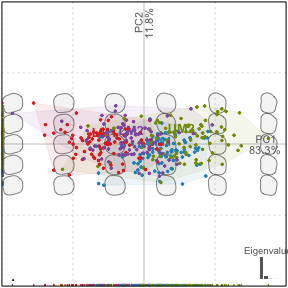

```r
# and the a priori normalization
molars %>% efourier(norm=FALSE) %>% PCA() %>% plot("type")
```

Finally, you can drop some harmonics with `rm_harm`. And methods that removes the bilateral (a)symmetry are implemented: `rm_asym` and `rm_sym`, while `symmetry` calculates some related indices.

### Open outlines

Open outlines are curves. Methods actually implemented are:

- `npoly` that fit natural polynomials;
- `opoly` that fit orthogonal (also called Legendre’s) polynomials;
- `dfourier` for the discrete cosine transform.

Note that `opoly` and `npoly` can only be used on *simple* curves, curves that have at most one `y` for any `x` coordinates, at least under a given orientation. `dfourier` can fit *complex* curves, curves “that back on their feets”.

Here, we will work on the fertile valves of olive stones, a (very partial) dataset provided by my colleagues Terral, Ivorra, and others.

They have two orthogonal views (a lateral and a dorsal view). See the paper cited in `?olea` for more details. Let’s explore it a bit:

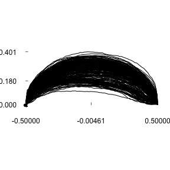

```r
olea
pile(olea)     # already aligned \o/
```

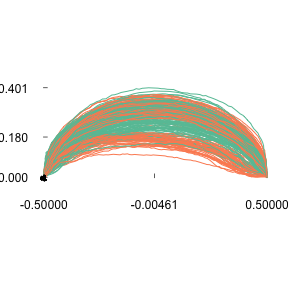

[output not shown]

```r
pile(olea, ~view)    # another family picture
```

Now, we gonna calculate `opoly` on it and plot the result of the PCA. Notice how consistent is the grammar and the objects obtained:

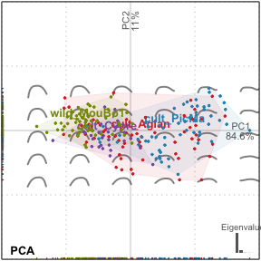

```
## [1] "OpnCoe" "Coe"
## [1] "PCA"    "prcomp"
```

```r
op <- opoly(olea)           # orthogonal polynomials
class(op)                   # an OpnCoe, but also a Coe
op.p <- PCA(op)             # we calculate a PCA on it
class(op.p)                 # a PCA object
plot(PCA(op), ~domes+var)   # notice the formula interface to combine factors
```

But this is perfectly wrong! We merged the two views are if they were different individuals. Momocs can first `chop` or `filter` the whole dataset to separate the two views, do morphometrics on them, and `combine` them afterwards.

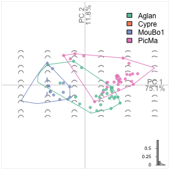

```
##     var
## view Aglan Cypre MouBo1 PicMa
##   VD    30    30     30    30
##   VL    30     0     30    30
## An OpnCoe object [ combined: opoly + opoly analyses ]
## --------------------
##  - $coe: 90 open outlines described
##  - $baseline1: (-0.5; 0; -0.5; 0)
##  - $baseline2: (0.5; 0; 0.5; 0)
## # A tibble: 90 x 4
##   var   domes view  ind
##   <fct> <fct> <fct> <fct>
## 1 Aglan cult  VD    O10
## 2 Aglan cult  VD    O11
## 3 Aglan cult  VD    O12
## 4 Aglan cult  VD    O13
## 5 Aglan cult  VD    O14
## 6 Aglan cult  VD    O15
## # ... with 84 more rows
```

```r
with(olea$fac, table(view, var))
# we drop 'Cypre' since there is no VL for 'Cypre' var
olea %>% filter(var != "Cypre") %>%
# split, do morphometrics, combine
chop(~view) %>% opoly %>% combine() %T>%
# we print the OpnCoe object, then resume to the pipe
print() %>%
# note the two views in the morphospace
PCA() %>% plot_PCA(~var)
```

Now the PCA is done on the combination of two `OpnCoe` objects, each one resulting from an independant `opoly` call. That is the meaning of the `[ combined: opoly + opoly analyses ]` printed by the pipe above. Momocs can combine up to four different views.

### Configuration of landmarks

_Landmarks methods are still quite experimental (i.e. not tested extensively)

Let’s have a look to graphics facilities and apply a full generalized Procrustes adjustment:

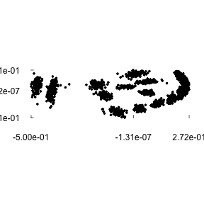

```r
pile(wings)
```

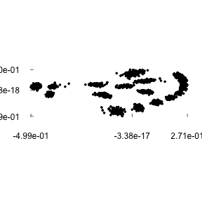

```r
w.al <- fgProcrustes(wings)
pile(w.al)
```

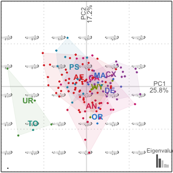

[output not shown]

```r
# PCA
PCA(w.al) %>% plot(1)
```

Sliding landmarks are supported and rely on `geomorph` package by D.C. Adams and E. Otarola-Castillo.

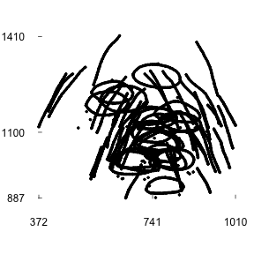

```r
pile(chaff)
```

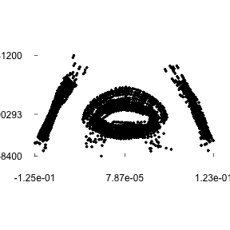

```r
chaff.al <- fgsProcrustes(chaff)
pile(chaff.al)
```

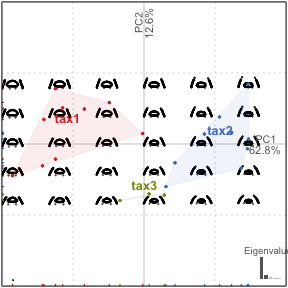

```r
chaff.al %>% PCA() %>% plot(~taxa, chull.filled=TRUE)
```

Again, the grammar is consistent for landmarks.

### Traditional morphometrics

Traditional morphometrics lose geometries: from the variables, you can’t unambiguously reconstruct the shape. Every shape is described by a combination of measurements, (inter landmark distance, quantitative variables, scalar descriptor, etc.)

Momocs provides some basics utilities to work with such objects in the `TraCoe` class. There is not `TraCoo` per se but it can be obtained from any `Coo` with the `measure` method. Let’s take the `hearts` dataset that comes from handdrawn heart shapes from my former colleagues at the French Intitute of Pondicherry:

[figure not shown]

```
## Out (outlines)
##   - 240 outlines, 80 +/- 0 coords (in $coo)
##   - 1 classifiers (in $fac):
## # A tibble: 240 x 1
##   aut
##   <fct>
## 1 ced
## 2 ced
## 3 ced
## 4 ced
## 5 ced
## 6 ced
## # ... with 234 more rows
##   - also: $ldk
```

```r
hearts
panel(hearts, fac="aut", names="aut")
```

Notice that there are 4 landmarks defined on them. Such landmarks on outlines can be: defined with`def_ldk()`, retrieved with `get_ldk()`, and overall used to align outlines with `fgProcrustes()`. You can compare: `hearts %>% stack()` with `hearts %>% fgProcrustes() %>% coo_slide(ldk=1) %>% stack()`.

Let’s describe these hearts with scalar descriptors: area, circularity and the distance between the 1st and the 3rd bumps of the hearts. `measure` is of great help. Note the loadings.

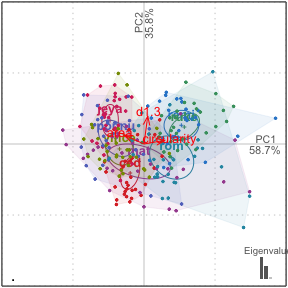

```
## [1] "TraCoe" "Coe"
## # A tibble: 240 x 3
##     area circularity   d1.3
##  * <dbl>       <dbl>  <dbl>
##  1 0.627        14.0 0.0695
##  2 0.593        14.5 0.0639
##  3 0.611        16.1 0.0699
##  4 0.539        15.7 0.0627
##  5 0.541        13.6 0.0613
##  6 0.611        16.0 0.0692
##  7 0.617        16.5 0.0755
##  8 0.535        15.8 0.0655
##  9 0.521        14.3 0.0622
## 10 0.546        15.2 0.0642
## # ... with 230 more rows
```

```r
ht <- measure(hearts, coo_area, coo_circularity, d(1, 3))
class(ht)
ht$coe
ht %>% PCA() %>% plot("aut", pch=20, ellipsesax=F, ellipse=T, loadings=T)
```

Again, there are plenty of scalar descriptors of shape, which names starts with `coo_*`, `apropos("coo_")`.

Such a `TraCoe` is provided in the `flower` dataset which is simply a rearranged `iris`. Once again, note the grammar consistency.

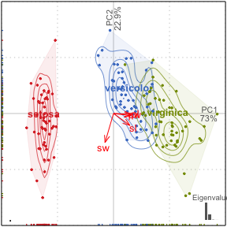

```
## A TraCoe object --------------------
##  - $coe: 150 shapes described with 4 variables
## # A tibble: 150 x 1
##   sp
##   <fct>
## 1 setosa
## 2 setosa
## 3 setosa
## 4 setosa
## 5 setosa
## 6 setosa
## # ... with 144 more rows
```

```r
flower
flower %>% PCA() %>% plot("sp", loadings=TRUE, contour=TRUE, lev.contour=5)
```

Note that, by default, PCA on `TraCoe` object first centers and scales variables. This can be changed, see `?PCA`.

## Multivariate statistics

This section will mainly be illustrated with `bot`, and consequently outline analysis, but it works the same on any `Coe` object, resulting from open outlines, configuration of landmarks, traditional morphometrics, etc.

```r
bot.f <- efourier(bot)
```

### `PCA`: Principal Component Analysis

Let’s see the main components of shape variability with a Principal Component Analysis.

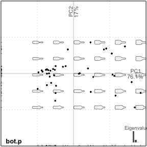

```r
bot.p <- PCA(bot.f)
plot(bot.p)
```

Morphological spaces are reconstructed on the fly with `plot.PCA`. We call it `plot.PCA` because it uses the familiar `plot` but on the particular `PCA` class (type `class(bot.p)`). We may want to display the two groups saved in `bot$fac`. Just type the id of the column or its name.

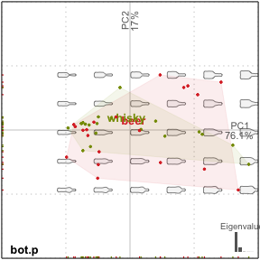

```r
plot(bot.p, "type") # equivalent to plot(bot.p, 1)
```

`plot.PCA` has many arguments and examples below will give a glimpse, but see `?plot.PCA` for the full list.

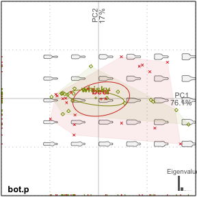

```r
plot(bot.p, 1, ellipses=TRUE, ellipsesax = FALSE, pch=c(4, 5))
```

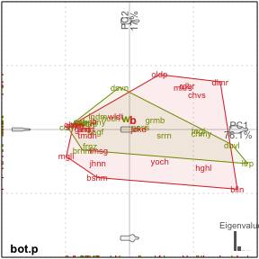

```r
plot(bot.p, 1, chull=TRUE, pos.shp = "full_axes", abbreviate.labelsgroups = TRUE, points=FALSE, labelspoints = TRUE)
```

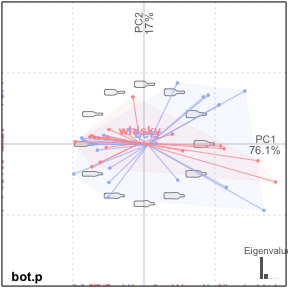

```r
plot(bot.p, 1, pos.shp="circle", stars=TRUE, chull.filled=TRUE, palette=col_spring)
```

You have a `ggplot2` alternative, that is not completely consistent:

```r
# plot2(bot.p, "type") # deprecated for the moment
```

And other helper functions for the `PCA` class:

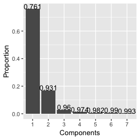

```r
scree(bot.p)
scree_plot(bot.p)
```

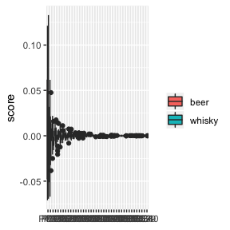

```r
boxplot(bot.p, 1)
```

[figure not shown]

[output not shown]

```r
PCcontrib(bot.p)
```

By the way, you can use Momocs plotters to plot non-morphometric datasets. Using a `TraCoe` object is an option, but `PCA` also works fine. Let’s see an example with `iris` dataset:

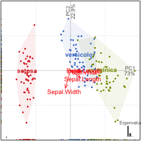

```r
TraCoe(iris[, -5], fac=data.frame(sp=iris$Species)) %>%
PCA() %>% plot("sp", loadings=TRUE)
```

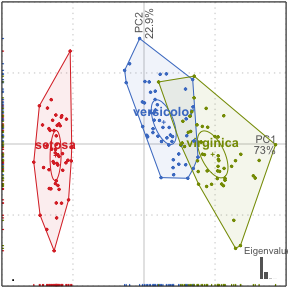

```r
# or
PCA(iris[, -5], fac=data.frame(sp=iris$Species)) %>%
plot("sp", chull=TRUE, ellipses=TRUE, conf_ellipses = 0.9)
```

### `LDA`: Linear Discriminant Analysis

We can also calculate a Linear Discriminant Analysis on the PCA scores, or on the `Coe` object, directly on the matrix of coefficients (and results may be better yet we may encounter collinearity between variables). Try the following:

```r
#LDA(bot.f, 1)
# we work on PCA scores
bot.l <- LDA(bot.p, 1)
# print a summary, along with the leave-one-out cross-validation table.
bot.l
# a much more detailed summary
bot.l %>% summary
# plot.LDA works pretty much with the same grammar as plot.PCA
# here we only have one LD
plot(bot.l)
# plot the cross-validation table
plot_CV(bot.l)  # tabular version
plot_CV(bot.l, freq=TRUE) # frequency table
plot_CV2(bot.l) # arrays version
```

Finally, if you need to classify using LDA methods, see `classify`.

### `MANOVA`: Multivariate Analysis of (co)variace

We can test for a difference in the distribution of PC scores with:

```r
MANOVA(bot.p, "type")
```

```
##           Df Hotelling-Lawley approx F num Df den Df   Pr(>F)
## fac        1           2.8388   12.977      7     32 8.88e-08 ***
## Residuals 38
## ---
## Signif. codes:  0 '***' 0.001 '**' 0.01 '*' 0.05 '.' 0.1 ' ' 1
```

We can also calculate pairwise combination between every levels of a `fac`. Here we just have two levels, so a single pairwise combination but the syntax is:

```r
MANOVA_PW(bot.p, "type")
```

```
## $stars.tab
##      beer whisky
## beer      ***
##
## $summary (see also $manovas)
##               Df Pillai approx F num Df den Df   Pr(>F)
## beer - whisky  1 0.7395    12.98      7     32 8.88e-08
```

If we want a MANCOVA instead :

```r
bot %<>% mutate(cs=coo_centsize(.))
bot %>% efourier %>% PCA %>% MANOVA("cs")
```

```
##           Df Hotelling-Lawley approx F num Df den Df Pr(>F)
## fac        1          0.32229   1.4733      7     32  0.212
## Residuals 38
```

### `CLUST`: Hierarchical clustering

A hierarchical classification now. It relies on `dist` + `hclust` + `ape::plot.phylo`.

```r
CLUST(bot.p, 1)
```

Monophyly is plotted by default. Many options can be found in `?CLUST`

### `KMEANS`: K-means clustering

A very minimal k-means clustering is implemented:

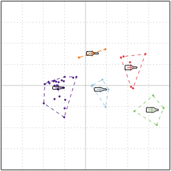

```
## K-means clustering with 5 clusters of sizes 5, 4, 6, 2, 23
##
## Cluster means:
##           PC1          PC2
## 1  0.02497106 -0.006671549
## 2  0.11318162 -0.041595869
## 3  0.07685254  0.030550337
## 4  0.01128098  0.054625628
## 5 -0.04614169 -0.004035307
##
## Clustering vector:
##         brahma          caney         chimay         corona    deusventrue
##              5              5              3              5              4
##          duvel   franziskaner     grimbergen        guiness     hoegardeen
##              2              5              1              1              5
##        jupiler     kingfisher       latrappe lindemanskriek    nicechouffe
##              5              5              2              5              5
##     pecheresse   sierranevada     tanglefoot          tauro      westmalle
##              5              1              3              5              5
##          amrut    ballantines      bushmills         chivas        dalmore
##              5              2              5              3              3
##   famousgrouse    glendronach   glenmorangie   highlandpark    jackdaniels
##              5              5              5              2              1
##             jb  johnniewalker       magallan     makersmark           oban
##              5              5              5              3              5
##     oldpotrero      redbreast         tamdhu     wildturkey         yoichi
##              4              3              5              5              1
##
## Within cluster sum of squares by cluster:
## [1] 0.001916822 0.002627386 0.004643234 0.001107903 0.011719347
##  (between_SS / total_SS =  87.8 %)
##
## Available components:
##
## [1] "cluster"      "centers"      "totss"        "withinss"
## [5] "tot.withinss" "betweenss"    "size"         "iter"
## [9] "ifault"
```

```r
KMEANS(bot.p, centers = 5)
```

### `mshapes`: Mean shapes

We can retrieve the mean shapes, group wise (if a `fac` is specified), or the global mean shape (if omitted). It works from the `Coe` object:

```r
# mean shape
bot.f %>% MSHAPES() %>% coo_plot()
# mean shape, per group
bot.ms <- mshapes(bot.f, 1)
beer   <- bot.ms$shp$beer    %T>% coo_plot(border="blue")
whisky <- bot.ms$shp$whisky  %T>% coo_draw(border="red")
legend("topright", lwd=1,
col=c("blue", "red"), legend=c("beer", "whisky"))
```

We can also plot a pairwise comparison of them:

```r
# leaves <- shapes %>% slice(grep("leaf", names(shapes))) %$% coo
# leaves %>% plot_mshapes(col2="#0000FF")

# or from mshapes directly
bot %>% efourier(6) %>% mshapes("type") %>% plot_mshapes
```

## Manipulating objects

### `dplyr` verbs

One common yet boring task of morphometrics consists in handling datasets: add new information, remove some individuals, etc.

Momocs adapts dplyr verbs to its objects, and add new ones. If you have never heard of dplyr, let’s have a look to its introduction [there](https://CRAN.R-project.org/package=dplyr), this may change your (R) life.

Basics verbs are implemented; try the following:

```r
data(olea)
olea
```

```
## Opn (curves)
##   - 210 curves, 99 +/- 4 coords (in $coo)
##   - 4 classifiers (in $fac):
## # A tibble: 210 x 4
##   var   domes view  ind
##   <fct> <fct> <fct> <fct>
## 1 Aglan cult  VD    O10
## 2 Aglan cult  VL    O10
## 3 Aglan cult  VD    O11
## 4 Aglan cult  VL    O11
## 5 Aglan cult  VD    O12
## 6 Aglan cult  VL    O12
## # ... with 204 more rows
##   - also: $ldk
```

```r
# slice: select individuals based on their position
slice(olea, 1:5)
```

```
## Opn (curves)
##   - 5 curves, 99 +/- 4 coords (in $coo)
##   - 4 classifiers (in $fac):
## # A tibble: 5 x 4
##   var   domes view  ind
##   <fct> <fct> <fct> <fct>
## 1 Aglan cult  VD    O10
## 2 Aglan cult  VL    O10
## 3 Aglan cult  VD    O11
## 4 Aglan cult  VL    O11
## 5 Aglan cult  VD    O12
##   - also: $ldk
```

```r
slice(olea, -(1:100))
```

```
## Opn (curves)
##   - 110 curves, 99 +/- 4 coords (in $coo)
##   - 4 classifiers (in $fac):
## # A tibble: 110 x 4
##   var   domes view  ind
##   <fct> <fct> <fct> <fct>
## 1 PicMa cult  VD    O15
## 2 PicMa cult  VL    O15
## 3 PicMa cult  VD    O16
## 4 PicMa cult  VL    O16
## 5 PicMa cult  VD    O17
## 6 PicMa cult  VL    O17
## # ... with 104 more rows
##   - also: $ldk
```

```r
# filter: select individual based on a logical condition
filter(olea, domes=="cult", view!="VD")
```

```
## Opn (curves)
##   - 60 curves, 97 +/- 4 coords (in $coo)
##   - 4 classifiers (in $fac):
## # A tibble: 60 x 4
##   var   domes view  ind
##   <fct> <fct> <fct> <fct>
## 1 Aglan cult  VL    O10
## 2 Aglan cult  VL    O11
## 3 Aglan cult  VL    O12
## 4 Aglan cult  VL    O13
## 5 Aglan cult  VL    O14
## 6 Aglan cult  VL    O15
## # ... with 54 more rows
##   - also: $ldk
```

```r
# select: pick, reorder columns from the $fac
select(olea, 1, Ind=ind)
```

```
## Opn (curves)
##   - 210 curves, 99 +/- 4 coords (in $coo)
##   - 2 classifiers (in $fac):
## # A tibble: 210 x 2
##   var   Ind
##   <fct> <fct>
## 1 Aglan O10
## 2 Aglan O10
## 3 Aglan O11
## 4 Aglan O11
## 5 Aglan O12
## 6 Aglan O12
## # ... with 204 more rows
##   - also: $ldk
```

```r
# mutate: add new columns
mutate(olea, fake=factor(rep(letters[1:2], each=105)))
```

```
## Opn (curves)
##   - 210 curves, 99 +/- 4 coords (in $coo)
##   - 5 classifiers (in $fac):
## # A tibble: 210 x 5
##   var   domes view  ind   fake
##   <fct> <fct> <fct> <fct> <fct>
## 1 Aglan cult  VD    O10   a
## 2 Aglan cult  VL    O10   a
## 3 Aglan cult  VD    O11   a
## 4 Aglan cult  VL    O11   a
## 5 Aglan cult  VD    O12   a
## 6 Aglan cult  VL    O12   a
## # ... with 204 more rows
##   - also: $ldk
```

```r
olea %>%
filter(domes=="cult", view=="VD") %>%
rename(domesticated=domes) %>%
select(-ind)
```

```
## Opn (curves)
##   - 90 curves, 100 +/- 2 coords (in $coo)
##   - 3 classifiers (in $fac):
## # A tibble: 90 x 3
##   var   domesticated view
##   <fct> <fct>        <fct>
## 1 Aglan cult         VD
## 2 Aglan cult         VD
## 3 Aglan cult         VD
## 4 Aglan cult         VD
## 5 Aglan cult         VD
## 6 Aglan cult         VD
## # ... with 84 more rows
##   - also: $ldk
```

This should save some headaches.

### New verbs ala `dplyr`

New verbs are implemented: for instance, you can `chop` (a rougher slicing) according to a condition: this will create a list, on which you can apply further operations, then `combine` it back. This is particularly useful when you want to apply independant treatments to different partitions, eg orthogonal views of your model. Prior to this, we can use `table` to cross-tabulate data from `$fac`. We could have done the first step of what follows with `rm_uncomplete` that drops (if any) missing data.

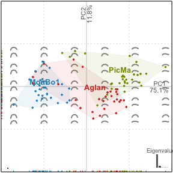

```
##         view
## var      VD VL
##   Aglan  30 30
##   Cypre  30  0
##   MouBo1 30 30
##   PicMa  30 30
```

```r
with(olea$fac, table(var, view))
# we drop 'Cypre' since there is no VL for 'Cypre' var
olea %>% filter(var != "Cypre") %>%
  # split, do morphometrics, combine
  chop(~view) %>% opoly %>% combine() %>%
  # note the two views in the morphospace
  PCA() %>% plot("var")
```

Also if you need some `group_by` operation, you can use the `fac` `data.frame`. For instance if you want to `arrange` based on a column and retain the top 10 shapes, then you can:

```r
retain <- x$fac %>%
# here we sort and create an id
arrange(your_column) %>% mutate(.id=1:n()) %>%
dplyr::group_by(taxa) %>% slice(1:10) %$% .id
# it worked!
x %>% slice(retain) %$% table(fac$taxa)
```

### Various helpers

Some methods help, on `Coe` objects to: * select groups with at least a certain number of individuals in them: `at_least` * removes outliers : `which_out` * sample a given number: `sample_n`; * sample a given proportion: `sample_frac`; * generate new individuals based on calibrated Gaussian coefficient generation: `breed`; * generate new individuals based on permutations: `perm`.

Several shortcuts are implemented on `Coo` and `Coe` objects: * `names` returns shape names; * `length` returns their number; * `table` cross-tabulates the`$fac` component; * `Ntable` does the same job and plots a confusion matrix; * `[]` extracts one (or more) shape; * `$` can access either a shape name or a column name for the `$fac`.

Try the following:

```r
names(bot)
length(bot)
table(olea, "var", "domes")
bot[1]
bot[1:5]
bot$brahma
bot$type
```

## Babel import/export

There are various morphometrics formats in the wild, almost as much as softwares. Momocs tries to create bridges between them, all gathered in the **Babel** family.

### Bridges within R

You can convert from/to array, matrix, list or data.frame with the functions `{a, m, l, d}2{a, m, l, d}`. For instance, `l2a` converts a list into an array that you can use with `geomorph`; `a2l` does the inverse operation.

Imagine you want to import pupfish from `geomorph` as a `Ldk` object:

```r
library(geomorph)
data(pupfish)
str(pupfish)
# so $coords will become $coo, and
# all other components will be turned into a data.frame to feed $fac
# with a single line
Ldk(coo=pupfish$coords %>% a2l,
  fac=pupfish[-1] %>% as.data.frame())
```

### Import from StereoMorph

If you use this excellent package by Olsen to digitize landmarks and curves, you can import them, from the files produced with the functions `import_StereoMorph_ldk` and `import_StereoMorph_curve`.

### Import from tps and other digitizing softwares

- `.tps` files can be read with `import_tps`
- `.nts` files an be read with `nts2Coo` (will be turned into `import_nts` soon)

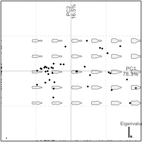

```r
# we simulate an imported matrix of coordinates, eg from a .csv
coeffs_from_the_wild <- bot %>% efourier(6) %$% coe
coeffs_in_Momocs <- OutCoe(coe=coeffs_from_the_wild, method="efourier", norm=TRUE)
coeffs_in_Momocs %>% PCA %>% plot
```

### Import misc

- If covariables are encoded in filenames, which is a good practice, eg if you have files named `spA_group7_ind4_VL.{txt|jpg|etc.}`, use `lf_structure`;
- If you need rewriting rules on your `$fac`, `rw_rule` is your friend;
- If you need to rescale imported coordinates, see `rescale`;
- If you need to tie images (eg outlines) and `.txt` (eg coordinates of landmarks on them), see `tie_jpg_txt`.

### Save from R

The best way to save a Momocs object is probably to use the base `save` function. You can call it back afterwards with `load`:

```r
save(bot, file="Bottles.rda")
# closing R, going to the beach, back at work
load("Bottles.rda") # bot is back
```

### Export from R

Any Momocs object, `Coo`s, `Coe`s, `PCA`s, etc. can be turned into a `data.frame` with `as_df`. Work with `dplyr`, `ggplot2` is made easy and you can export it as `.txt`, `.csv` “by hand” or use the `export` function:

```r
bot %>% as_df # then %>% write.table
bot %>% efourier %>% export
bot %>% efourier %>% PCA %>% export
```

But, of course, you can directly access information within the Momocs objects; try the following:

```r
# from Coo objects
bot$coo # list of matrices (of xy coordinates)
bot$fac # data.frame for covariates

# from Coe objects
bot.f$coe # matrix of coefficients
bot.f$fac # data.frame for covariates
as_df(bot.f)

# from PCA objects
bot.p$x        # scores
bot.p$rotation # rotation matrix
```

## Graphics

### `tps_*`: Thin Plate Splines

TPS have not been presented before but here there are:

```
tps_grid(beer, whisky)
tps_arr(beer, whisky)
tps_iso(beer, whisky)
```

Again, plenty options in `?tps_*`.

You may also like lolliplots and friends:

```r
coo_lolli(beer, whisky); title("coo_lolli")
coo_arrows(beer, whisky); title("coo_arrow")

# an example with coo_ruban
coo_plot(beer) # to get the first plot
coo_ruban(beer, edm(beer, whisky), lwd=8) # we add ruban based from deviations
coo_draw(whisky)
title("coo_ruban")
```

### `ggplot2`

Many graphical function have their `ggplot2` counterpart:

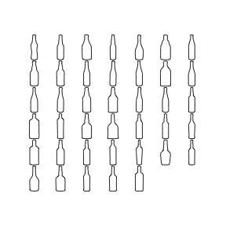

```r
panel(bot)
```

Otherwise, you can build your own plots. Let’s begin with a simple example:

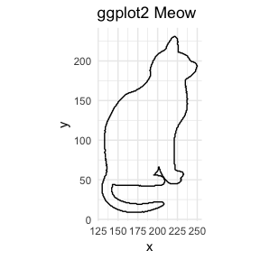

```r
# we build a ggplot object from a shape turned into a data.frame
library(ggplot2)
shapes[4] %>% m2d() %>% ggplot() +
aes(x, y) + geom_path() + coord_equal() +
labs(title="ggplot2 Meow") + theme_minimal()
```

Here is a more complicated plot that takes profit of `as_df` methods that turns objects into `ggplot2`-friendly `data.frame`s:

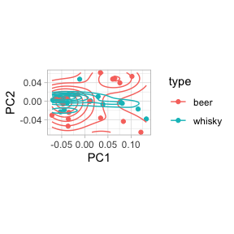

```r
bot.p %>% as_df() %>% ggplot() +
aes(x=PC1, y=PC2, col=type) + coord_equal() +
geom_point() + geom_density2d() + theme_light()
```

### Color palettes

- Nice palettes are bundled with Momocs, see `?palettes`.

## Frequently asked questions

- **How to access all methods for a given class?**
- `methods(class="your_class")`, eg `methods(class="Opn")`
- **How to access methods defined for a particular function?**
- `methods("your_function")`, eg `methods("fgProcrustes")`
- **How can I access help for a particular methods?**
- `function.class`, eg `?plot.PCA`
- **How can I access the code of a method?**
- For functions, just type its name, eg `lf_structure`; for methods add its class, eg `plot.PCA`
- **To be continued**
- Done with love by Vincent Bonhomme `<bonhomme.vincent@gmail.com>`.
- Help/suggestions/review/critics are welcome.
- Sources are [there](https://github.com/MomX/Momocs/tree/master/vignettes)